# topic_lda

### Sample program for Topic Model Analysis using gensim (LDA)

#### Import libraries

```python
import numpy as np
import pandas as pd
import matplotlib.pyplot as plt
from gensim.models.ldamodel import LdaModel
from gensim.corpora.dictionary import Dictionary
from gensim.parsing.preprocessing import preprocess_string
from gensim.parsing.preprocessing import strip_tags, strip_numeric
from gensim.parsing.preprocessing import remove_stopwords, strip_punctuation
```

#### Parameters

```python
csv_in = 'newsgroups5-1.csv'

model_file = 'topic_newsgroups5-1.model'
```

#### Read CSV file

```python
df = pd.read_csv(csv_in, delimiter=',', skiprows=0, header=0)
print(df.shape)
print(df.info())
display(df.head())
```

```
(2975, 3)
<class 'pandas.core.frame.DataFrame'>
RangeIndex: 2975 entries, 0 to 2974
Data columns (total 3 columns):
 #   Column        Non-Null Count  Dtype
---  ------        --------------  -----
 0   content       2975 non-null   object
 1   target        2975 non-null   int64
 2   target_names  2975 non-null   object
dtypes: int64(1), object(2)
memory usage: 69.9+ KB
None
```

|  | content | target | target_names |
| --- | --- | --- | --- |
| 0 | I was wondering if anyone out there could en... | 0 | rec.autos |
| 1 | There were a few people who responded to my r... | 3 | sci.med |
| 2 | I recently posted an article asking what... | 0 | rec.autos |
| 3 | I would like to be able to amplify a voltag... | 4 | sci.electronics |
| 4 | Wayne Alan Martin <wm1h+@andrew.cmu.edu>>Exce... | 4 | sci.electronics |

#### Check the number of documents in each category

```python
print(df['target'].value_counts())
n_targets = df['target'].value_counts().shape[0]
print(n_targets)
```

```
1    599
2    597
0    594
3    594
4    591
Name: target, dtype: int64
5
```

#### Assign docID according to its category

- docID = 'd' + number, such as d0, d1, ..., d1000, d1001, ...
  - number = target * 1000 + j

```python
docID = []
j = np.zeros(n_targets)
for i in range(len(df)):
    tgt = df.at[i, 'target']
    # base of document ID:
    #   0 for documents of target 0, 1000 for documents of target 1,
    #   2000 for documents of target 2, ...
    docID.append('d'+str(int(tgt*1000+j[tgt])))
    # increment j for target "tgt"
    j[tgt] += 1
df['docID'] = docID
display(df.head())
```

|  | content | target | target_names | docID |
| --- | --- | --- | --- | --- |
| 0 | I was wondering if anyone out there could en... | 0 | rec.autos | d0 |
| 1 | There were a few people who responded to my r... | 3 | sci.med | d3000 |
| 2 | I recently posted an article asking what... | 0 | rec.autos | d1 |
| 3 | I would like to be able to amplify a voltag... | 4 | sci.electronics | d4000 |
| 4 | Wayne Alan Martin <wm1h+@andrew.cmu.edu>>Exce... | 4 | sci.electronics | d4001 |

### Remove stop_words, punctuations, etc.

- Use custom filters
- in this case, strip_multiple_whiltespaces is not used.

```python
CUSTOM_FILTERS = [lambda x: x.lower(),
                  strip_tags, remove_stopwords,
                  strip_punctuation, strip_numeric,
                 ]
df['content'] = df['content'].map(lambda y: preprocess_string(y, CUSTOM_FILTERS))
display(df.head())
```

|  | content | target | target_names | docID |
| --- | --- | --- | --- | --- |
| 0 | [wondering, enlighten, car, saw, day, door, sp... | 0 | rec.autos | d0 |
| 1 | [people, responded, request, info, treatment, ... | 3 | sci.med | d3000 |
| 2 | [recently, posted, article, asking, kind, rate... | 0 | rec.autos | d1 |
| 3 | [like, able, amplify, voltage, signal, output,... | 4 | sci.electronics | d4000 |
| 4 | [wayne, alan, martin, excerpts, from, sites, r... | 4 | sci.electronics | d4001 |

Non-significant words are omitted.  
Now the value of "content" column is a list of words.

#### Build dictionary

```python
dic = Dictionary(df['content'])
print('#docs:', dic.num_docs)
print('#vocabulary_size:', len(dic))
print('#words_in_total:', dic.num_pos)
```

```
#docs: 2975
#vocabulary_size: 32242
#words_in_total: 362098
```

#### Check frequency of each word in corpus

```python
df_dic = pd.DataFrame([])
df_dic['word_id'] = list(dic.cfs.keys())
df_dic['word'] = df_dic['word_id'].map(dic)
df_dic['frequency'] = list(dic.cfs.values())
df_dic_sorted = df_dic.sort_values('frequency', ascending=False)
display(df_dic_sorted.head())
display(df_dic_sorted.tail())
```

|  | word_id | word | frequency |
| --- | --- | --- | --- |
| 229 | 189 | edu | 2174 |
| 76 | 97 | article | 1806 |
| 318 | 180 | dont | 1539 |
| 494 | 512 | like | 1505 |
| 637 | 583 | it | 1382 |

|  | word_id | word | frequency |
| --- | --- | --- | --- |
| 23058 | 23062 | zlttg | 1 |
| 11108 | 11012 | overbeek | 1 |
| 11106 | 10927 | icot | 1 |
| 23061 | 23059 | saadi | 1 |
| 32241 | 32232 | aneurysm | 1 |

#### Filter word set (omit too less / too much frequent words)

- no_below: Minimum frequency of a word for the analysis
- no_above: Maximum ratio of appearance in documents (omit words appeared in too many docs)

```python
dic.filter_extremes(no_below=5, no_above=0.1)
print('#docs:', dic.num_docs)
print('#vocabulary_size:', len(dic))
print('#words_in_total:', dic.num_pos)
```

```
#docs: 2975
#vocabulary_size: 8734
#words_in_total: 362098
```

**After the filtering, the vocabulary size is shrinked**

#### Check frequency of each word in corpus after filtering

```python
df_dic = pd.DataFrame([],)
df_dic['word_id'] = list(dic.cfs.keys())
df_dic['word'] = df_dic['word_id'].map(dic)
df_dic['frequency'] = list(dic.cfs.values())
df_dic_sorted = df_dic.sort_values('frequency', ascending=False)
display(df_dic_sorted.head())
display(df_dic_sorted.tail())
```

|  | word_id | word | frequency |
| --- | --- | --- | --- |
| 1569 | 1550 | jesus | 569 |
| 481 | 480 | power | 436 |
| 1566 | 1532 | church | 417 |
| 653 | 640 | help | 410 |
| 1745 | 1732 | c | 402 |

|  | word_id | word | frequency |
| --- | --- | --- | --- |
| 7538 | 7538 | nusunix | 5 |
| 8144 | 8146 | discovering | 5 |
| 6715 | 6704 | chairman | 5 |
| 8150 | 8151 | replicate | 5 |
| 8733 | 8733 | thorough | 5 |

#### Make corpus (BoW for each document)

```python
corpus = [dic.doc2bow(text) for text in df['content']]
print('corpus:')
print(corpus[:2])
```

```
corpus:
[[(0, 1), (1, 1), (2, 1), (3, 1), (4, 1), (5, 1), (6, 1), (7, 1), (8, 1), (9, 1), (10, 1), (11, 1), (12, 1), (13, 1), (14, 1), (15, 1), (16, 1), (17, 1), (18, 1), (19, 1), (20, 1), (21, 1), (22, 1), (23, 1), (24, 1), (25, 1), (26, 1), (27, 1), (28, 1), (29, 1)], [(13, 1), (18, 1), (30, 1), (31, 1), …
```

#### Calculation of LDA

- Set n_topics = 5 for example (same as the number of newsgroups)
- Set alpha = 'symmetric', i.e. prior probability for each topic is uniform

```python
n_topics = 5
alpha = 'symmetric'
lda = LdaModel(corpus, num_topics=n_topics, alpha=alpha, random_state=1)
```

#### Topic probability for each doc

- A list of (topic_id, topic_probability)

```python
# Show topic prob for the 1st 7 documents as samples
for c in corpus[:7]:
    doc_topics = lda.get_document_topics(c)
    print(doc_topics)
```

```
[(3, 0.97350836)]
[(1, 0.9670763)]
[(0, 0.08092678), (1, 0.22186877), (2, 0.1863232), (3, 0.4720981), (4, 0.03878312)]
[(2, 0.9776542)]
[(1, 0.027526304), (2, 0.24286774), (4, 0.721087)]
[(0, 0.897968), (1, 0.02543956), (2, 0.025815342), (3, 0.025385298), (4, 0.025391806)]
[(1, 0.011619691), (3, 0.11402477), (4, 0.87077427)]
```

#### Correspondence between category (newsgroup) and topics

- Average probability of topics of documents for each category

```python
cat_topics = np.zeros((n_targets, n_topics))
n_tgt_docs = np.zeros(n_targets)
tgt_names = ['']*n_targets
for i in range(dic.num_docs):
    target_id = df.at[i, 'target']
    if tgt_names[target_id] == '':
        tgt_names[target_id] = df.at[i, 'target_names']
    n_tgt_docs[target_id] += 1
    for topic_id,topic_prob in lda.get_document_topics(corpus[i]):
        cat_topics[target_id, topic_id] += topic_prob

for i in range(n_targets):
    cat_topics[i, :] /= n_tgt_docs[i]

df_cat_topics = pd.DataFrame(cat_topics)
df_cat_topics['target_names'] = tgt_names
display(df_cat_topics)
```

|  | 0 | 1 | 2 | 3 | 4 | target_names |
| --- | --- | --- | --- | --- | --- | --- |
| 0 | 0.107392 | 0.208199 | 0.090245 | 0.474506 | 0.109173 | rec.autos |
| 1 | 0.163237 | 0.089591 | 0.093462 | 0.100152 | 0.545368 | soc.religion.christian |
| 2 | 0.715456 | 0.131204 | 0.026008 | 0.083518 | 0.032021 | rec.sport.baseball |
| 3 | 0.056671 | 0.077673 | 0.483159 | 0.246148 | 0.125470 | sci.med |
| 4 | 0.108929 | 0.315111 | 0.184206 | 0.141007 | 0.240051 | sci.electronics |

#### Word probability for each topic

```python
n_top = 5
for i in range(n_topics):
    print('Topic #{}'.format(i))
    for word_id,prob in lda.get_topic_terms(i, topn=n_top):
        print(dic[word_id], prob)
    print('')
```

```
Topic #0
team 0.0035015976
game 0.0033728639
runs 0.0029200732
cubs 0.0025363585
baseball 0.0024994207

Topic #1
help 0.002870711
chip 0.002623395
cars 0.0021323476
c 0.0020778163
cs 0.0020367082

Topic #2
patients 0.0022466572
disease 0.0020659042
marriage 0.0019920038
information 0.0019607611
research 0.0017547725

Topic #3
msg 0.0030478255
k 0.0023349142
c 0.0021630367
food 0.0020246168
pain 0.0019665305

Topic #4
jesus 0.006735112
bible 0.0038257816
law 0.003458671
power 0.0030756325
hell 0.003021045
```

#### Visualization of word probability using wordcloud

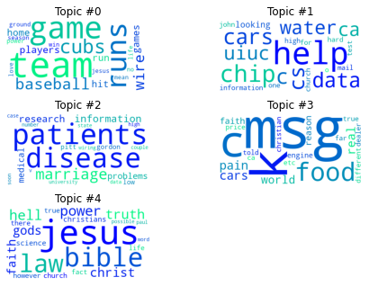

```python
from wordcloud import WordCloud

wc = WordCloud(
    background_color="white",
    colormap="winter",
    collocations=False,
)

fig = plt.figure(figsize=(6,8))
fig.subplots_adjust(left=0, right=1, bottom=0, top=0.5, hspace=0.3)
for i in range(n_topics):
    plt.subplot(3,2,i+1)
    x = {dic[t[0]]:t[1] for t in lda.get_topic_terms(i, topn=20)}
    im = wc.generate_from_frequencies(x)
    plt.imshow(im)
    plt.axis('off')
    plt.title('Topic #'+str(i))
plt.show()
```

It seems that correspondence between categories (newsgroups) and topics exists.  
Note that probability of topics is determined per document, not per newsgroup, and various subjects are included in articles of a newsgroup (e.g. NOT all articles in rec.sports.baseball talk about baseball)

Target 0 (rec.autos): mainly generated from topics #1 and #3.  
Target 1 (soc.religion.christian): mainly generated from topic #4.  
Target 2 (rec.sport.baseball): mainly generated from topic #0.  
Target 3 (sci.med): mainly generated from topics #2 and #3.  
Target 4 (sci.electronics): mainly generated from topics #1 and #4.